# USL Part 3: Market Basket Analysis

Evrim Bilgen

12/17/2021

# **Market Basket Analysis /Association Rules**

## Our packages

```r
library(arules)
```

```r
library(arulesViz)
library(datasets)
library(tidyverse)
library(plyr)
library(ggplot2)
library(knitr)
library(lubridate)
library(RColorBrewer)
library(tibble)
```

## Import the dataset & Convert it

```r
data <- read.csv('/Users/ewrimmm/Desktop/R exercises/USL_21/Grocery.csv')
```

## Data cleaning and exploration

```r
glimpse(data)
```

```
## Rows: 7,500
## Columns: 20
## $ shrimp            <chr> "burgers", "chutney", "turkey", "mineral water", "lo…
## $ almonds           <chr> "meatballs", "", "avocado", "milk", "", "french frie…
## $ avocado           <chr> "eggs", "", "", "energy bar", "", "", "shallot", "gr…
## $ vegetables.mix    <chr> "", "", "", "whole wheat rice", "", "", "", "", "", …
## $ green.grapes      <chr> "", "", "", "green tea", "", "", "", "", "", "", "",…
## $ whole.weat.flour  <chr> "", "", "", "", "", "", "", "", "", "", "", "", "", …
## $ yams              <chr> "", "", "", "", "", "", "", "", "", "", "", "", "", …
## $ cottage.cheese    <chr> "", "", "", "", "", "", "", "", "", "", "", "", "", …
## $ energy.drink      <chr> "", "", "", "", "", "", "", "", "", "", "", "", "", …
## $ tomato.juice      <chr> "", "", "", "", "", "", "", "", "", "", "", "", "", …
## $ low.fat.yogurt    <chr> "", "", "", "", "", "", "", "", "", "", "", "", "", …
## $ green.tea         <chr> "", "", "", "", "", "", "", "", "", "", "", "", "", …
## $ honey             <chr> "", "", "", "", "", "", "", "", "", "", "", "", "", …
## $ salad             <chr> "", "", "", "", "", "", "", "", "", "", "", "", "", …
## $ mineral.water     <chr> "", "", "", "", "", "", "", "", "", "", "", "", "", …
## $ salmon            <chr> "", "", "", "", "", "", "", "", "", "", "", "", "", …
## $ antioxydant.juice <chr> "", "", "", "", "", "", "", "", "", "", "", "", "", …
## $ frozen.smoothie   <chr> "", "", "", "", "", "", "", "", "", "", "", "", "", …
## $ spinach           <chr> "", "", "", "", "", "", "", "", "", "", "", "", "", …
## $ olive.oil         <lgl> NA, NA, NA, NA, NA, NA, NA, NA, NA, NA, NA, NA, NA, …
```

```r
head(data)
```

```
##              shrimp      almonds    avocado   vegetables.mix green.grapes
## 1           burgers    meatballs       eggs
## 2           chutney
## 3            turkey      avocado
## 4     mineral water         milk energy bar whole wheat rice    green tea
## 5    low fat yogurt
## 6 whole wheat pasta french fries
##   whole.weat.flour yams cottage.cheese energy.drink tomato.juice low.fat.yogurt
## 1
## 2
## 3
## 4
## 5
## 6
##   green.tea honey salad mineral.water salmon antioxydant.juice frozen.smoothie
## 1
## 2
## 3
## 4
## 5
## 6
##   spinach olive.oil
## 1                NA
## 2                NA
## 3                NA
## 4                NA
## 5                NA
## 6                NA
```

```r
sum(is.na(data))
```

```
## [1] 7500
```

```r
summary(data)
```

```
##     shrimp            almonds            avocado          vegetables.mix
##  Length:7500        Length:7500        Length:7500        Length:7500
##  Class :character   Class :character   Class :character   Class :character
##  Mode  :character   Mode  :character   Mode  :character   Mode  :character
##  green.grapes       whole.weat.flour       yams           cottage.cheese
##  Length:7500        Length:7500        Length:7500        Length:7500
##  Class :character   Class :character   Class :character   Class :character
##  Mode  :character   Mode  :character   Mode  :character   Mode  :character
##  energy.drink       tomato.juice       low.fat.yogurt      green.tea
##  Length:7500        Length:7500        Length:7500        Length:7500
##  Class :character   Class :character   Class :character   Class :character
##  Mode  :character   Mode  :character   Mode  :character   Mode  :character
##     honey              salad           mineral.water         salmon
##  Length:7500        Length:7500        Length:7500        Length:7500
##  Class :character   Class :character   Class :character   Class :character
##  Mode  :character   Mode  :character   Mode  :character   Mode  :character
##  antioxydant.juice  frozen.smoothie      spinach          olive.oil
##  Length:7500        Length:7500        Length:7500        Mode:logical
##  Class :character   Class :character   Class :character   NA's:7500
##  Mode  :character   Mode  :character   Mode  :character
```

## Convert the data

```r
data = read.transactions('/Users/ewrimmm/Desktop/R exercises/USL_21/Grocery.csv', sep = ',', rm.duplicates = TRUE)
```

```
## distribution of transactions with duplicates:
## 1
## 5
```

Lets see the top 20 products that sold in the dataset

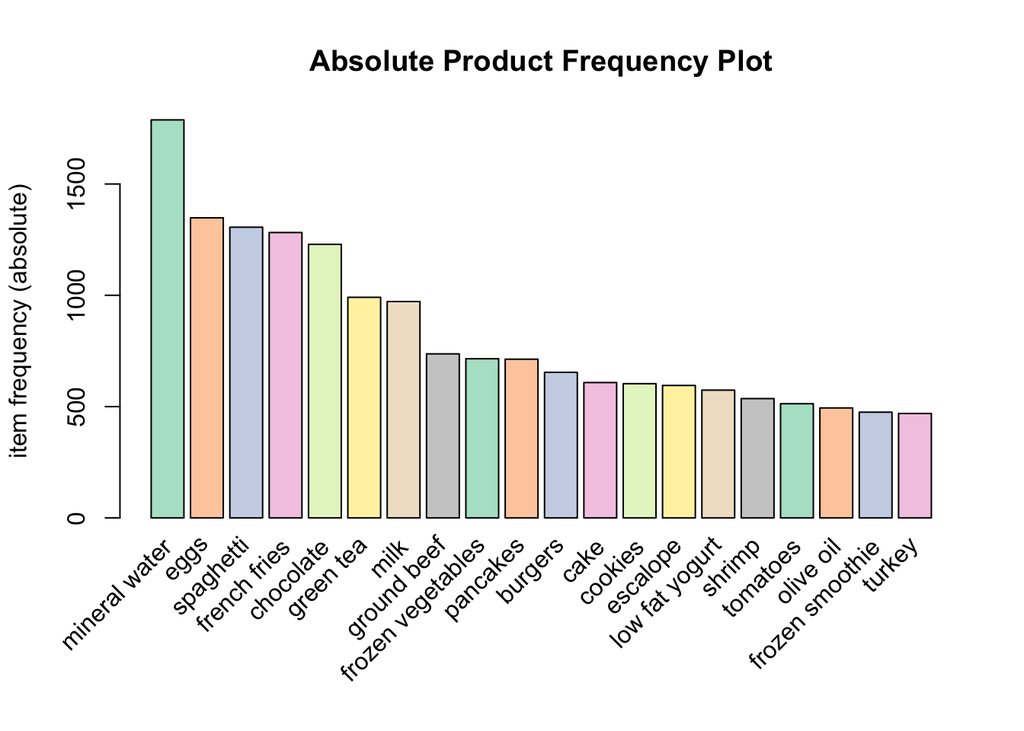

```r
itemFrequencyPlot(data,topN=20,type="absolute",col=brewer.pal(8,'Pastel2'), main="Absolute Product Frequency Plot")
```

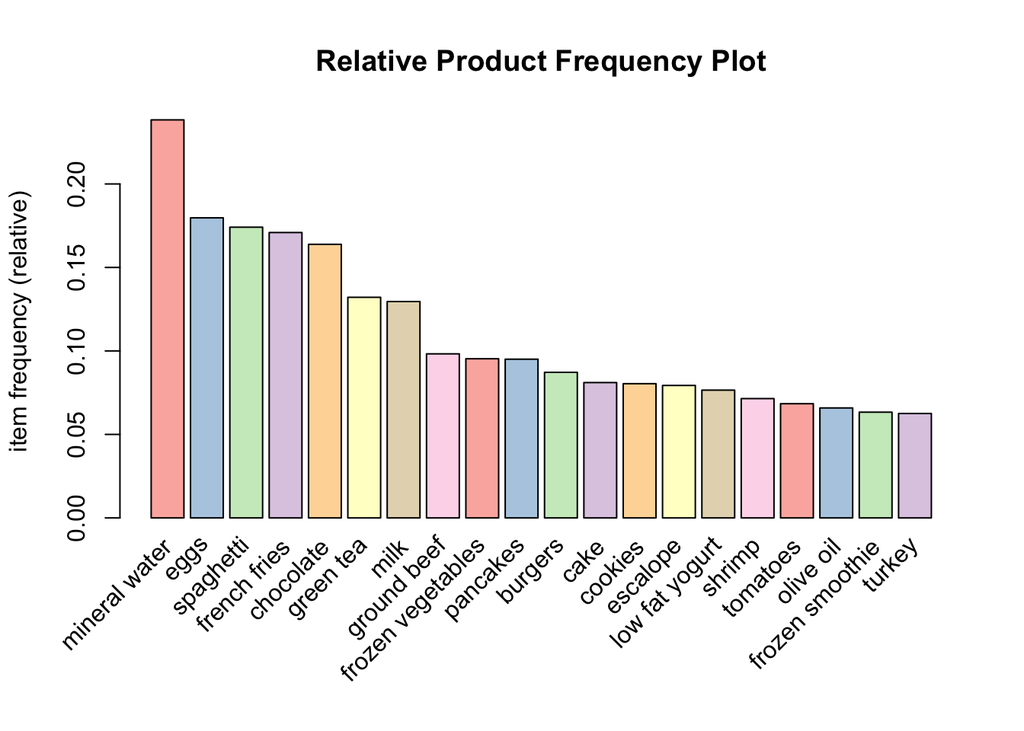

```r
itemFrequencyPlot(data,topN=20,type="relative",col=brewer.pal(8,'Pastel1'), main="Relative Product Frequency Plot")
```

First we go with the numeric frequencies showed how independence from each others by using absolute type. Then we choose the relative type to show these products appeared.

## Apriori Algorithm

What is Apriori Algorithm?

*‘’Apriori is an algorithm for frequent item set mining and association rule learning over relational databases. It proceeds by identifying the frequent individual items in the database and extending them to larger and larger item sets as long as those item sets appear sufficiently often in the database.’’*

Now it’s time to setting the rules. I am going to do these three steps;

- the minimum support to 0.001
- the minimum confidence of 0.8
- then interpret the summary of rules

# Min Support as 0.001, confidence as 0.8.

```r
myrules <- apriori(data, parameter = list(supp=0.001, conf=0.8,maxlen=10))
```

```
## Apriori
##
## Parameter specification:
##  confidence minval smax arem  aval originalSupport maxtime support minlen
##         0.8    0.1    1 none FALSE            TRUE       5   0.001      1
##  maxlen target  ext
##      10  rules TRUE
##
## Algorithmic control:
##  filter tree heap memopt load sort verbose
##     0.1 TRUE TRUE  FALSE TRUE    2    TRUE
##
## Absolute minimum support count: 7
##
## set item appearances ...[0 item(s)] done [0.00s].
## set transactions ...[119 item(s), 7501 transaction(s)] done [0.00s].
## sorting and recoding items ... [116 item(s)] done [0.00s].
## creating transaction tree ... done [0.00s].
## checking subsets of size 1 2 3 4 5 6 done [0.01s].
## writing ... [74 rule(s)] done [0.00s].
## creating S4 object  ... done [0.00s].
```

We have 74 rules and most of rules are 4 items long.

```r
summary(myrules)
```

```
## set of 74 rules
##
## rule length distribution (lhs + rhs):sizes
##  3  4  5  6
## 15 42 16  1
##
##    Min. 1st Qu.  Median    Mean 3rd Qu.    Max.
##   3.000   4.000   4.000   4.041   4.000   6.000
##
## summary of quality measures:
##     support           confidence        coverage             lift
##  Min.   :0.001067   Min.   :0.8000   Min.   :0.001067   Min.   : 3.356
##  1st Qu.:0.001067   1st Qu.:0.8000   1st Qu.:0.001333   1st Qu.: 3.432
##  Median :0.001133   Median :0.8333   Median :0.001333   Median : 3.795
##  Mean   :0.001256   Mean   :0.8504   Mean   :0.001479   Mean   : 4.823
##  3rd Qu.:0.001333   3rd Qu.:0.8889   3rd Qu.:0.001600   3rd Qu.: 4.877
##  Max.   :0.002533   Max.   :1.0000   Max.   :0.002666   Max.   :12.722
##      count
##  Min.   : 8.000
##  1st Qu.: 8.000
##  Median : 8.500
##  Mean   : 9.419
##  3rd Qu.:10.000
##  Max.   :19.000
##
## mining info:
##  data ntransactions support confidence
##  data          7501   0.001        0.8
```

Our top 20 output will be sorted by confidence.

So we can see that with 100% confidence, the customer bought french fries,mushroom cream sauce,pasta also bought escalope And it is followed by the rest three rows respectively with %100 confidence which means the most likely rules.

```r
inspect(sort(myrules,by='confidence', decreasing=TRUE)[1:20])
```

```
##      lhs                       rhs                 support confidence    coverage      lift count
## [1]  {french fries,
##       mushroom cream sauce,
##       pasta}                => {escalope}      0.001066524  1.0000000 0.001066524 12.606723     8
## [2]  {ground beef,
##       light cream,
##       olive oil}            => {mineral water} 0.001199840  1.0000000 0.001199840  4.195190     9
## [3]  {cake,
##       meatballs,
##       mineral water}        => {milk}          0.001066524  1.0000000 0.001066524  7.717078     8
## [4]  {cake,
##       olive oil,
##       shrimp}               => {mineral water} 0.001199840  1.0000000 0.001199840  4.195190     9
## [5]  {mushroom cream sauce,
##       pasta}                => {escalope}      0.002532996  0.9500000 0.002666311 11.976387    19
## [6]  {red wine,
##       soup}                 => {mineral water} 0.001866418  0.9333333 0.001999733  3.915511    14
## [7]  {eggs,
##       mineral water,
##       pasta}                => {shrimp}        0.001333156  0.9090909 0.001466471 12.722185    10
## [8]  {herb & pepper,
##       mineral water,
##       rice}                 => {ground beef}   0.001333156  0.9090909 0.001466471  9.252498    10
## [9]  {ground beef,
##       pancakes,
##       whole wheat rice}     => {mineral water} 0.001333156  0.9090909 0.001466471  3.813809    10
## [10] {frozen vegetables,
##       milk,
##       spaghetti,
##       turkey}               => {mineral water} 0.001199840  0.9000000 0.001333156  3.775671     9
## [11] {chocolate,
##       frozen vegetables,
##       olive oil,
##       shrimp}               => {mineral water} 0.001199840  0.9000000 0.001333156  3.775671     9
## [12] {frozen smoothie,
##       spinach}              => {mineral water} 0.001066524  0.8888889 0.001199840  3.729058     8
## [13] {black tea,
##       spaghetti,
##       turkey}               => {eggs}          0.001066524  0.8888889 0.001199840  4.946258     8
## [14] {light cream,
##       mineral water,
##       shrimp}               => {spaghetti}     0.001066524  0.8888889 0.001199840  5.105326     8
## [15] {cake,
##       meatballs,
##       milk}                 => {mineral water} 0.001066524  0.8888889 0.001199840  3.729058     8
## [16] {grated cheese,
##       mineral water,
##       rice}                 => {ground beef}   0.001066524  0.8888889 0.001199840  9.046887     8
## [17] {cake,
##       olive oil,
##       whole wheat pasta}    => {mineral water} 0.001066524  0.8888889 0.001199840  3.729058     8
## [18] {escalope,
##       hot dogs,
##       mineral water}        => {milk}          0.001066524  0.8888889 0.001199840  6.859625     8
## [19] {brownies,
##       eggs,
##       ground beef}          => {mineral water} 0.001066524  0.8888889 0.001199840  3.729058     8
## [20] {chicken,
##       fresh bread,
##       pancakes}             => {mineral water} 0.001066524  0.8888889 0.001199840  3.729058     8
```

## Visualizing the Association Rules

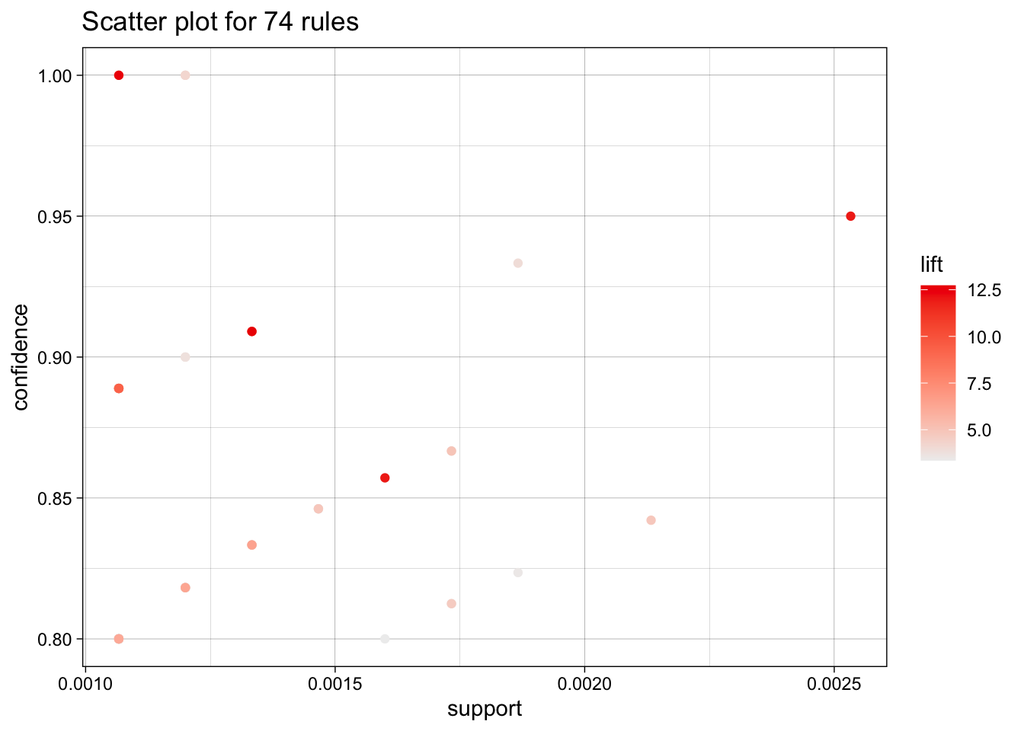

```r
plot(myrules, jitter = 0)
```

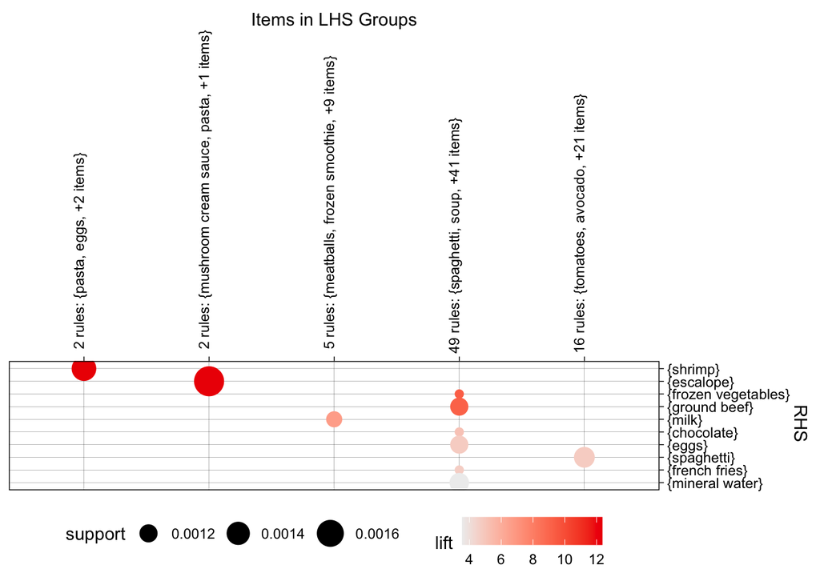

```r
plot(myrules, method = "grouped", control = list(k = 5))
```

And the graph of our first 20 rules

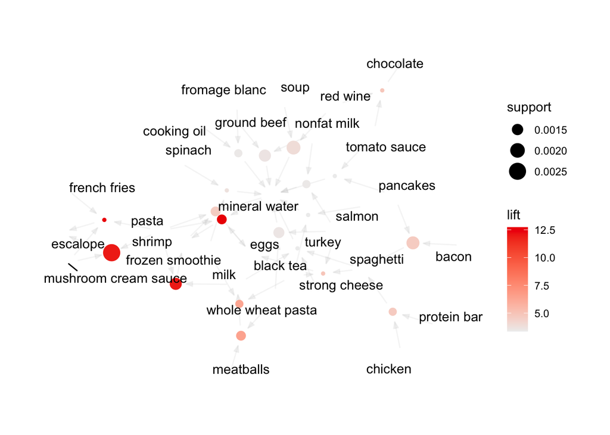

```r
plot(myrules[1:20], method="graph")
```

If we set another subrules with different parametres for having another relevant- likely rules(for redundancy) and plot it using two-key plot:

```r
mysubrules <- apriori(data, parameter = list(minlen=3, sup = 0.001, conf = 0.4))
```

```
## Apriori
##
## Parameter specification:
##  confidence minval smax arem  aval originalSupport maxtime support minlen
##         0.4    0.1    1 none FALSE            TRUE       5   0.001      3
##  maxlen target  ext
##      10  rules TRUE
##
## Algorithmic control:
##  filter tree heap memopt load sort verbose
##     0.1 TRUE TRUE  FALSE TRUE    2    TRUE
##
## Absolute minimum support count: 7
##
## set item appearances ...[0 item(s)] done [0.00s].
## set transactions ...[119 item(s), 7501 transaction(s)] done [0.00s].
## sorting and recoding items ... [116 item(s)] done [0.00s].
## creating transaction tree ... done [0.00s].
## checking subsets of size 1 2 3 4 5 6 done [0.01s].
## writing ... [2739 rule(s)] done [0.00s].
## creating S4 object  ... done [0.00s].
```

```
## To reduce overplotting, jitter is added! Use jitter = 0 to prevent jitter.
```

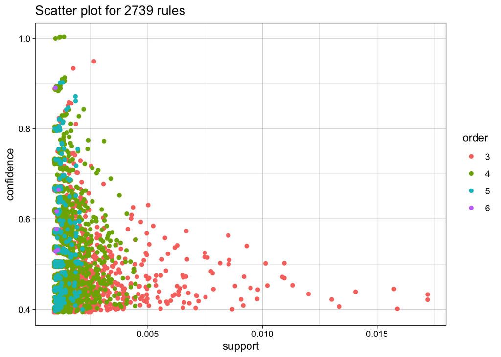

```r
plot(mysubrules,method="two-key plot")
```

So we basically analysed the market basket analysis with Apriori algorithm.

## Referances

- https://www.datacamp.com/community/tutorials/market-basket-analysis-r
- https://towardsdatascience.com/a-gentle-introduction-on-market-basket-analysis-association-rules-fa4b986a40ce
- kaggle
- https://stackoverflow.com/